# KOU_DataAnalysisMethod_assingment2

Hosub Park

2016년 5월 8일

## <9주>

### 1. In the graft.vs.host data set, estimate the survival function for patients with or without GVHD. Test the hypothesis that the survival is the same in both groups. Extend the analysis by including the other explanatory variables.

loading data

```r
library(ISwR)
data("graft.vs.host")
ghdata <- graft.vs.host
```

#### **Estimate the survival function for patients with or without GVHD.**

[figure not shown]

```r
library(survival)

ghdata$type <- factor(ghdata$type, labels=c("AML", "ALL", "CML"))
ghdata$preg <- factor(ghdata$preg, labels=c("No", "Yes"))
ghdata$gvhd <- factor(ghdata$gvhd, labels=c("No", "Yes"))
ghdata$dead <- factor(ghdata$dead, labels=c("No", "Yes"))

SV <- Surv(ghdata$time, ghdata$dead == "Yes")
SVgvhd <- survfit(SV~ghdata$gvhd, data=ghdata)
plot(SVgvhd, col=c("red","blue"), lty=c(1,1), main="Survival curve btw GVHD", ylab="Survival rate", xlab="Months")
legend(x= "topright", legend = c("GVHD positive", "GVHD negative"), col= c("red","blue"), lty=c(1,1))
```

```r
coxph(SV~gvhd, data=ghdata)
```

```
## Call:
## coxph(formula = SV ~ gvhd, data = ghdata)
##
##          coef exp(coef) se(coef)    z     p
## gvhdYes 1.242     3.462    0.514 2.41 0.016
##
## Likelihood ratio test=6.19  on 1 df, p=0.0129
## n= 37, number of events= 18
```

GVHD만을 고려하였을때 GVHD가 있는 경우 생존률이 더 나쁘다. 생존기간에 관계없이 GVHD가 있는 경우는 없는 경우보다 사망가능성이 3.462배 더 높다.

#### **Test the hypothesis that the survival is the same in both groups.**

```r
survdiff(SV~gvhd, data=ghdata)
```

```
## Call:
## survdiff(formula = SV ~ gvhd, data = ghdata)
##
##           N Observed Expected (O-E)^2/E (O-E)^2/V
## gvhd=No  20        7    11.99      2.07      6.55
## gvhd=Yes 17       11     6.01      4.14      6.55
##
##  Chisq= 6.6  on 1 degrees of freedom, p= 0.0105
```

P값이 0.0105이므로 두 그룹간의 survival의 차이가 없다는 귀무가설을 기각할 수 있으므로, GVHD의 유무에 따라 survival에 유의한 차이가 있다고 할 수 있다.

#### **Extend the analysis by including the other explanatory variables.**

모든 변수를 넣고 modeling.

```r
summary(coxph(SV~rcpage+donage+type+preg+log(index)+gvhd, data=ghdata))
```

```
## Call:
## coxph(formula = SV ~ rcpage + donage + type + preg + log(index) +
##     gvhd, data = ghdata)
##
##   n= 37, number of events= 18
##
##                coef exp(coef) se(coef)      z Pr(>|z|)
## rcpage      0.00256   1.00256  0.04600  0.056   0.9556
## donage      0.02809   1.02849  0.04262  0.659   0.5098
## typeALL    -0.28624   0.75109  0.70097 -0.408   0.6830
## typeCML    -2.44519   0.08671  0.95315 -2.565   0.0103 *
## pregYes     0.23275   1.26207  0.74180  0.314   0.7537
## log(index) -0.38097   0.68320  0.41029 -0.929   0.3531
## gvhdYes     2.33557  10.33532  0.82018  2.848   0.0044 **
## ---
## Signif. codes:  0 '***' 0.001 '**' 0.01 '*' 0.05 '.' 0.1 ' ' 1
##
##            exp(coef) exp(-coef) lower .95 upper .95
## rcpage       1.00256    0.99744   0.91613    1.0972
## donage       1.02849    0.97230   0.94607    1.1181
## typeALL      0.75109    1.33140   0.19012    2.9673
## typeCML      0.08671   11.53272   0.01339    0.5616
## pregYes      1.26207    0.79235   0.29489    5.4013
## log(index)   0.68320    1.46371   0.30571    1.5268
## gvhdYes     10.33532    0.09676   2.07104   51.5774
##
## Concordance= 0.833  (se = 0.074 )
## Rsquare= 0.47   (max possible= 0.957 )
## Likelihood ratio test= 23.51  on 7 df,   p=0.001389
## Wald test            = 22.53  on 7 df,   p=0.002057
## Score (logrank) test = 26.49  on 7 df,   p=0.0004121
```

rcpage 제외

```r
summary(coxph(SV~donage+type+preg+log(index)+gvhd, data=ghdata))
```

```
## Call:
## coxph(formula = SV ~ donage + type + preg + log(index) + gvhd,
##     data = ghdata)
##
##   n= 37, number of events= 18
##
##                coef exp(coef) se(coef)      z Pr(>|z|)
## donage      0.02924   1.02967  0.03722  0.785  0.43217
## typeALL    -0.26310   0.76866  0.56567 -0.465  0.64184
## typeCML    -2.43254   0.08781  0.92532 -2.629  0.00857 **
## pregYes     0.24558   1.27837  0.70459  0.349  0.72743
## log(index) -0.37060   0.69032  0.36446 -1.017  0.30922
## gvhdYes     2.33988  10.38001  0.81636  2.866  0.00415 **
## ---
## Signif. codes:  0 '***' 0.001 '**' 0.01 '*' 0.05 '.' 0.1 ' ' 1
##
##            exp(coef) exp(-coef) lower .95 upper .95
## donage       1.02967    0.97119   0.95722    1.1076
## typeALL      0.76866    1.30096   0.25365    2.3293
## typeCML      0.08781   11.38777   0.01432    0.5385
## pregYes      1.27837    0.78225   0.32130    5.0864
## log(index)   0.69032    1.44861   0.33793    1.4102
## gvhdYes     10.38001    0.09634   2.09560   51.4145
##
## Concordance= 0.831  (se = 0.074 )
## Rsquare= 0.47   (max possible= 0.957 )
## Likelihood ratio test= 23.51  on 6 df,   p=0.0006432
## Wald test            = 22.56  on 6 df,   p=0.0009595
## Score (logrank) test = 26.48  on 6 df,   p=0.0001814
```

preg 제외

```r
summary(coxph(SV~donage+type+log(index)+gvhd, data=ghdata))
```

```
## Call:
## coxph(formula = SV ~ donage + type + log(index) + gvhd, data = ghdata)
##
##   n= 37, number of events= 18
##
##                coef exp(coef) se(coef)      z Pr(>|z|)
## donage      0.03467   1.03528  0.03303  1.050 0.293879
## typeALL    -0.24634   0.78165  0.57151 -0.431 0.666439
## typeCML    -2.55743   0.07750  0.85891 -2.978 0.002906 **
## log(index) -0.37698   0.68593  0.36744 -1.026 0.304917
## gvhdYes     2.48310  11.97837  0.72314  3.434 0.000595 ***
## ---
## Signif. codes:  0 '***' 0.001 '**' 0.01 '*' 0.05 '.' 0.1 ' ' 1
##
##            exp(coef) exp(-coef) lower .95 upper .95
## donage        1.0353    0.96592    0.9704    1.1045
## typeALL       0.7817    1.27934    0.2550    2.3960
## typeCML       0.0775   12.90262    0.0144    0.4173
## log(index)    0.6859    1.45787    0.3338    1.4095
## gvhdYes      11.9784    0.08348    2.9031   49.4234
##
## Concordance= 0.825  (se = 0.074 )
## Rsquare= 0.469   (max possible= 0.957 )
## Likelihood ratio test= 23.39  on 5 df,   p=0.0002845
## Wald test            = 21.83  on 5 df,   p=0.0005632
## Score (logrank) test = 24.09  on 5 df,   p=0.0002084
```

index제외

```r
summary(coxph(SV~donage+type+gvhd, data=ghdata))
```

```
## Call:
## coxph(formula = SV ~ donage + type + gvhd, data = ghdata)
##
##   n= 37, number of events= 18
##
##             coef exp(coef) se(coef)      z Pr(>|z|)
## donage   0.04466   1.04567  0.03161  1.413 0.157657
## typeALL -0.14272   0.86700  0.55035 -0.259 0.795383
## typeCML -2.64609   0.07093  0.85907 -3.080 0.002069 **
## gvhdYes  2.12887   8.40537  0.60539  3.517 0.000437 ***
## ---
## Signif. codes:  0 '***' 0.001 '**' 0.01 '*' 0.05 '.' 0.1 ' ' 1
##
##         exp(coef) exp(-coef) lower .95 upper .95
## donage    1.04567     0.9563   0.98286     1.112
## typeALL   0.86700     1.1534   0.29482     2.550
## typeCML   0.07093    14.0988   0.01317     0.382
## gvhdYes   8.40537     0.1190   2.56596    27.534
##
## Concordance= 0.803  (se = 0.073 )
## Rsquare= 0.453   (max possible= 0.957 )
## Likelihood ratio test= 22.33  on 4 df,   p=0.0001721
## Wald test            = 20.5  on 4 df,   p=0.0003974
## Score (logrank) test = 23.46  on 4 df,   p=0.0001026
```

donage제외

```r
summary(coxph(SV~type+gvhd, data=ghdata))
```

```
## Call:
## coxph(formula = SV ~ type + gvhd, data = ghdata)
##
##   n= 37, number of events= 18
##
##             coef exp(coef) se(coef)      z Pr(>|z|)
## typeALL -0.04537   0.95565  0.55440 -0.082 0.934783
## typeCML -2.52955   0.07969  0.84987 -2.976 0.002916 **
## gvhdYes  2.29593   9.93370  0.60242  3.811 0.000138 ***
## ---
## Signif. codes:  0 '***' 0.001 '**' 0.01 '*' 0.05 '.' 0.1 ' ' 1
##
##         exp(coef) exp(-coef) lower .95 upper .95
## typeALL   0.95565     1.0464   0.32240    2.8327
## typeCML   0.07969    12.5479   0.01507    0.4215
## gvhdYes   9.93370     0.1007   3.05022   32.3512
##
## Concordance= 0.745  (se = 0.071 )
## Rsquare= 0.423   (max possible= 0.957 )
## Likelihood ratio test= 20.37  on 3 df,   p=0.0001425
## Wald test            = 18.81  on 3 df,   p=0.0002997
## Score (logrank) test = 21.72  on 3 df,   p=7.453e-05
```

**GVHD가 있는 경우가 없는 경우에 비해 9.9배 사망위험이 높고, AML에 비해 CML환자에서 사망위험률이 0.07배 이다.**

### 2. Fit Cox models to the stroke data with age and sex as predictors and with sex alone. Explain the difference.

loading data

```r
library(ISwR)
data(stroke)
```

Cox model with age and sex

```r
library(survival)
SV <- Surv(stroke$obsmonths, stroke$dead==TRUE)
summary(coxph(SV~age+sex, data=stroke))
```

```
## Call:
## coxph(formula = SV ~ age + sex, data = stroke)
##
##   n= 829, number of events= 485
##
##             coef exp(coef) se(coef)      z Pr(>|z|)
## age     0.049289  1.050524 0.004374 11.268   <2e-16 ***
## sexMale 0.022332  1.022584 0.100717  0.222    0.825
## ---
## Signif. codes:  0 '***' 0.001 '**' 0.01 '*' 0.05 '.' 0.1 ' ' 1
##
##         exp(coef) exp(-coef) lower .95 upper .95
## age         1.051     0.9519    1.0416     1.060
## sexMale     1.023     0.9779    0.8394     1.246
##
## Concordance= 0.66  (se = 0.014 )
## Rsquare= 0.174   (max possible= 0.999 )
## Likelihood ratio test= 158.6  on 2 df,   p=0
## Wald test            = 137.7  on 2 df,   p=0
## Score (logrank) test = 136.3  on 2 df,   p=0
```

Cox model with sex alone

```r
summary(coxph(SV~sex, data=stroke))
```

```
## Call:
## coxph(formula = SV ~ sex, data = stroke)
##
##   n= 829, number of events= 485
##
##             coef exp(coef) se(coef)      z Pr(>|z|)
## sexMale -0.36571   0.69371  0.09615 -3.803 0.000143 ***
## ---
## Signif. codes:  0 '***' 0.001 '**' 0.01 '*' 0.05 '.' 0.1 ' ' 1
##
##         exp(coef) exp(-coef) lower .95 upper .95
## sexMale    0.6937      1.442    0.5746    0.8376
##
## Concordance= 0.547  (se = 0.012 )
## Rsquare= 0.018   (max possible= 0.999 )
## Likelihood ratio test= 14.97  on 1 df,   p=0.0001091
## Wald test            = 14.47  on 1 df,   p=0.0001428
## Score (logrank) test = 14.63  on 1 df,   p=0.0001311
```

Age와 sex 두 변수를 같이 사용한 Cox model에서는 sex가 유의하지 않은 변수(p=0.825)로 나왔지만 sex만 을 사용한 Cox model에서는 유의한 변수(p=0.000143)로 나타났다.

우선 age와 sex의 상관관계를 보면

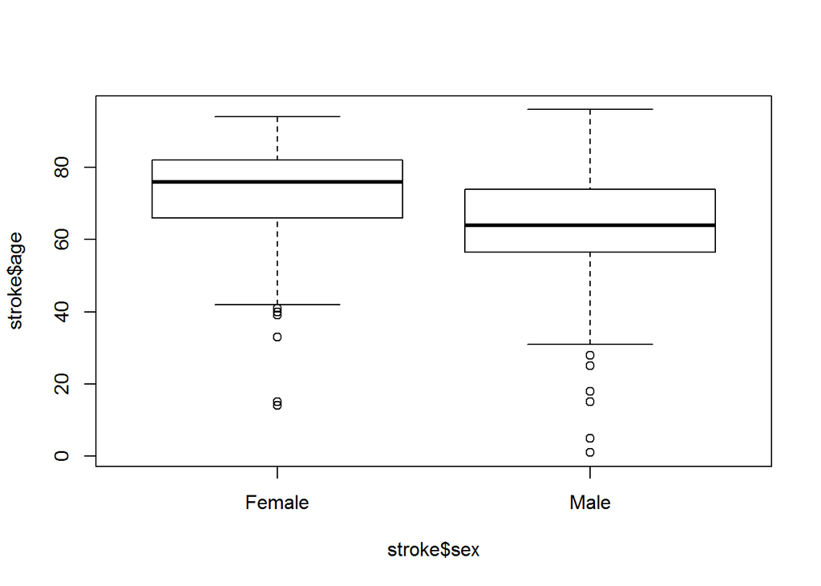

```r
plot(stroke$age~stroke$sex)
```

```r
t.test(stroke$age~stroke$sex)
```

```
##
##  Welch Two Sample t-test
##
## data:  stroke$age by stroke$sex
## t = 9.2356, df = 602.97, p-value < 2.2e-16
## alternative hypothesis: true difference in means is not equal to 0
## 95 percent confidence interval:
##   7.038872 10.840949
## sample estimates:
## mean in group Female   mean in group Male
##             73.32549             64.38558
```

sex에 따라 age가 유의하게 차이가 있는 것을 알 수 있다. 또한 이 dataset에서 남성은 여성보다 9살 정도 평균연령이 낮다.

Age가 survival에 미치는 영향을 보면

```r
summary(coxph(SV~age, data=stroke))
```

```
## Call:
## coxph(formula = SV ~ age, data = stroke)
##
##   n= 829, number of events= 485
##
##         coef exp(coef) se(coef)     z Pr(>|z|)
## age 0.049001  1.050221 0.004177 11.73   <2e-16 ***
## ---
## Signif. codes:  0 '***' 0.001 '**' 0.01 '*' 0.05 '.' 0.1 ' ' 1
##
##     exp(coef) exp(-coef) lower .95 upper .95
## age      1.05     0.9522     1.042     1.059
##
## Concordance= 0.66  (se = 0.014 )
## Rsquare= 0.174   (max possible= 0.999 )
## Likelihood ratio test= 158.6  on 1 df,   p=0
## Wald test            = 137.7  on 1 df,   p=0
## Score (logrank) test = 136.2  on 1 df,   p=0
```

연령이 1살 증가할 수록 사망위험률이 1.05배 증가함을 알 수 있다.

따라서 성별에 따라 연령분포가 다르기 때문에 성별만을 놓고 보았을때 성별에 따른 생존의 차이가 있다는 결과가 나올 수 있고, 성별과 연령을 같이 고려하면 성별에 따른 연령분포 차이의 효과없이 성별이 생존에 미치는 영향만을 얻을 수 있기 때문에 두 Cox 모델의 차이가 나타난다.